# Monte Carlo analysis of Bitcoin

Lukas Läderach

# Abstract

This document describes the process of modeling a bitcoin monte carlo chart.

# Prerequisites

To follow along this notebook make sure the following R-Packages are installed globally.

```r
# Quandl - Get millions of financial and economic datasets from hundreds of publishers directly into R.
install.packages("Quandl")
# ggplot2 is a plotting system for R, based on the grammar of graphics.
install.packages("ggplot2")
```

Once those packages are installed import them into your current workspace and set your Quandl API-Key (You have to create an account at [Quandl](https://www.quandl.com/sign-up-modal?defaultModal=showSignUp)).

Once everthing is set up correctly you should be able retrieve financial data via Quandl.

For example the following statement will retrieve all the BTC/USD starting from 2017-12-31 to the very recent.

```r
data <- Quandl("BITFINEX/BTCUSD", start_date="2017-12-31")
head(data)
```

```
        Date     High      Low     Mid   Last    Bid    Ask   Volume
1 2018-05-02 9268.727 8968.300 9244.05 9244.0 9244.0 9244.1 19388.66
2 2018-05-01 9254.300 8817.975 9059.95 9060.0 9059.9 9060.0 25728.75
3 2018-04-30 9450.000 9100.000 9178.20 9178.0 9178.1 9178.3 23226.31
4 2018-04-29 9565.100 9180.000 9412.80 9412.6 9412.6 9413.0 26595.99
5 2018-04-28 9500.000 8750.000 9333.35 9333.4 9333.3 9333.4 45431.34
6 2018-04-27 9381.100 8929.000 9059.95 9060.0 9059.9 9060.0 31678.95
```

To generate a plot visualizing the closing price according to it’s date (column labeled *Last*) we can specify which columns to retrieve via the column_index parameter (0 is always the *Date* column). To specifiy multiple columns we can also create a vector e.g. *c(4,6)* - this would return a table containing the *Date*, *Last* and *Ask* columns only.

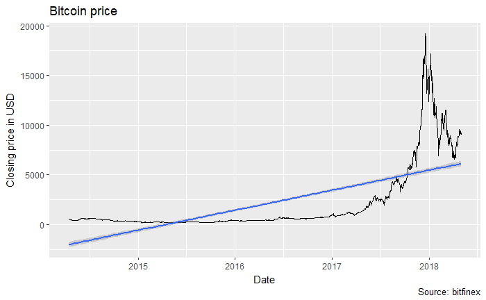

```r
data <- Quandl("BITFINEX/BTCUSD", start_date="2011-12-31", column_index=4)
gg <- ggplot(data, aes(Date, Last)) +
  geom_line() +
  geom_smooth(method = "lm") +
  labs(title="Bitcoin price",
       y="Closing price in USD",
       caption="Source: bitfinex")
plot(gg)
```

# Introduction

## Brownian Motion

**Main Idea** - There are two parts to random movement

- Deterministic Component, known as Drift
- Stochastic Component, known as Random Shock

```
Future Price = Today's Price * Continuous Growth over time + The volatility of People randomly trading over time
```

```r
gg = Quandl("BITFINEX/BTCUSD", start_date="2011-12-31", transform = "rdiff")
```

```
Error in names(frame) <- `*vtmp*` : names() applied to a non-vector
```

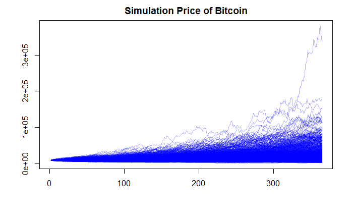

```r
lmtRets = gg$Last
mu = mean(lmtRets) # also knwon as Drift
sigma = sd(lmtRets)
nSim = 1000
nDays = 365
S0 <- head(Quandl("BITFINEX/BTCUSD", start_date="2018-5-1"), n=1)$Last
S = matrix(0,nrow=nDays,ncol=nSim)
for (i in 1:nSim) {
  SVec = rep(0, nDays)
  SVec[1] = S0
  for(j in 2:nDays) {
    pastDay = SVec[j-1]
    DeltaS = mu*pastDay + sigma*pastDay*rnorm(1)
    SVec[j] = pastDay+DeltaS
  }
  S[,i] = SVec
}
matplot(S, type='l',col=rgb(0,0,1,0.3), lty=1,ylab="", main="Simulation Price of Bitcoin")
```

```r
lnMean = S0*exp(mu*nDays)
lnSD = S0*exp(mu*nDays)*sqrt(exp((sigma^2)*nDays)-1)
cat(lnMean,mean(S[nDays,]))
```

```
25858.62 26272.2
```

```r
cat(lnSD,sd(S[nDays,]))
```

```
23136.06 24430.41
```

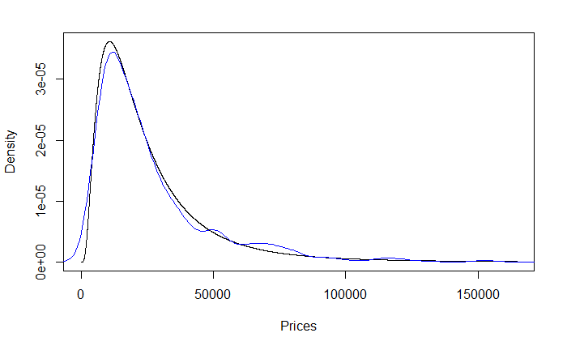

```r
meanOfLog = log(S0) + (mu-(sigma^2)/2)*nDays
sdOfLog = sigma*sqrt(nDays)
priceGrid = seq(0,lnMean+6*lnSD,length=10000)
theoreticalDens = dlnorm(priceGrid,meanOfLog,sdOfLog)
empiricalDens = density(S[nDays,])
plot(priceGrid,theoreticalDens,type='l',xlab='Prices',ylab='Density')
lines(empiricalDens,col='blue')
```